# Stepwise Regression Building European Public Opinion and Defense Spending

Greg Sanders and Samantha Cohen

June 17, 2016

# 1 Setup

## 1.1 Load Packages and Support Files

```
## Version:  1.36.4
## Date:     2016-02-16
## Author:   Philip Leifeld (Eawag & University of Bern)
##
```

```
## Version 0.4-0 included new data defaults. See ?getSymbols.
```

## 1.2 Load the Data

## 1.3 Subset the Data

The samples for the two hypotheses that involve courses that the EU should pursue exclude Turkey, which is not yet a member nation. Poland and Slovakia both joined in 2004 and the question was only asked of their populaces after they joined. This question has a different mean for non-members, because it does not necessarily reflect and desired direction for their own country. All the sample countries are NATO members, so none need be excluded from NATO essential.

# 2 Building the regression model

## 2.1 Starting with Public Opinion model

```r
corrdisp<-rcorr(as.matrix(subset(EuropeOmnibus, select=c(DefSpread_lag1,
                                               EUldrSpread_lag1,
                                               NATOessSpread_lag1,
                                               EUcloserUSspread_lag1))))
corrdisp[[1]][,1:4]
```

```
##                       DefSpread_lag1 EUldrSpread_lag1 NATOessSpread_lag1 EUcloserUSspread_lag1
## DefSpread_lag1            1.00000000       -0.3564616        -0.09639107            0.01553688
## EUldrSpread_lag1         -0.35646161        1.0000000         0.44872284           -0.11282273
## NATOessSpread_lag1       -0.09639107        0.4487228         1.00000000           -0.33083811
## EUcloserUSspread_lag1     0.01553688       -0.1128227        -0.33083811            1.00000000
```

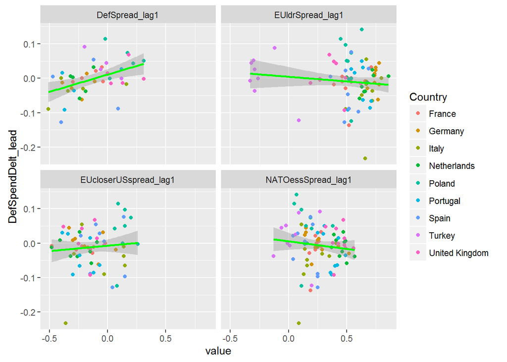

```r
PollingScatter <- melt(EuropeOmnibus, measure.vars = c("DefSpread_lag1",
                                           "EUldrSpread_lag1",
                                           "EUcloserUSspread_lag1",
                                           "NATOessSpread_lag1"))


    ggplot(data=PollingScatter,aes(x=value,
                            y=DefSpendDelt_lead,
                            color=Country))+geom_point()+
        facet_wrap(~variable)+geom_point()+stat_smooth(method = "lm", col = "green")
```

```r
lmMoreDef<-list()
lmEUldr<-list()
lmNATOess<-list()
lmEU_UScls<-list()
nModel<-c()

reg<-1
lmMoreDef[reg]<-list(lm(log(DefSpend_lead) ~ DefSpread_lag1, EuropeMoreDef))
lmEUldr[reg]<-list(lm(log(DefSpend_lead) ~ EUldrSpread_lag1, EuropeEUleadership))
lmNATOess[reg]<-list(lm(log(DefSpend_lead) ~ NATOessSpread_lag1, EuropeNATOess))
lmEU_UScls[reg]<-list(lm(log(DefSpend_lead) ~ EUcloserUSspread_lag1, EuropeOmnibus))
nModel[reg]<-"PubOp"


screenreg(c(lmMoreDef[1],
               lmEUldr[1],
               lmNATOess[1],
               lmEU_UScls[1]),
               custom.model.names=c(rep(nModel[1],4)),
          stars=c(0.001,0.01,0.05,0.1),
          # reorder.coef=c(1,2,5,9,11,6,3,4,7,10,8),
          groups = list("Intercept" = 1,"Polling" = 2:5))
```

```
##
## =====================================================================
##                            PubOp      PubOp      PubOp      PubOp
## ---------------------------------------------------------------------
## Intercept
##
##     (Intercept)            23.31 ***  24.00 ***  23.32 ***  23.35 ***
##                            (0.19)     (0.52)     (0.20)     (0.15)
## Polling
##
##     DefSpread_lag1          0.66
##                            (0.79)
##     EUldrSpread_lag1                  -0.93
##                                       (0.86)
##     NATOessSpread_lag1                            0.36
##                                                  (0.65)
##     EUcloserUSspread_lag1                                   -0.68
##                                                             (0.70)
## ---------------------------------------------------------------------
## R^2                         0.01       0.02       0.00       0.01
## Adj. R^2                   -0.01       0.00      -0.01      -0.00
## Num. obs.                  53         70         87         64
## RMSE                        1.22       0.98       0.95       0.99
## =====================================================================
## *** p < 0.001, ** p < 0.01, * p < 0.05, . p < 0.1
```

```r
                        # , "Security"=6,"Macroeconomic" = 7, "Parliamentary"=8:11))
```

Relationships do appear in the scatter plots for Defense Spread and EU closer to US. Those plots use the percent change in defense spending as a dependent variable, which resembles the way to interpret the meaning of a change in log, but they make it easier for humans to interpret. The next step is to move to the macroeconomic variables. These will capture much of the explaination for differences in defense spending, as military spending for NATO countries do tend to cluster somewhere beneath the 2 percent mark and thus are correlated to the size of the overall economy.

## 2.2 Macroeconomic Controls

### 2.2.1 Magnitude of the Economy

```r
corrdisp<-rcorr(as.matrix(subset(EuropeOmnibus, select=c(DefSpread_lag1,
                                               EUldrSpread_lag1,
                                               NATOessSpread_lag1,
                                               EUcloserUSspread_lag1,
                                               NGDP_eu2014,
                                               NGDPPC_eu2014,
                                               Population,
                                               GGR_eu2014))))
corrdisp[[1]][,5:8]
```

```
##                       NGDP_eu2014 NGDPPC_eu2014  Population  GGR_eu2014
## DefSpread_lag1        -0.09723692   -0.28288645  0.09140770 -0.17478040
## EUldrSpread_lag1       0.28386140    0.55528921 -0.29160669  0.33130622
## NATOessSpread_lag1     0.10135478    0.54870641 -0.37983257  0.06196413
## EUcloserUSspread_lag1 -0.15365438   -0.50169390  0.09653112 -0.15667027
## NGDP_eu2014            1.00000000    0.66023028  0.74543321  0.98083830
## NGDPPC_eu2014          0.66023028    1.00000000  0.08298811  0.66088724
## Population             0.74543321    0.08298811  1.00000000  0.71739531
## GGR_eu2014             0.98083830    0.66088724  0.71739531  1.00000000
```

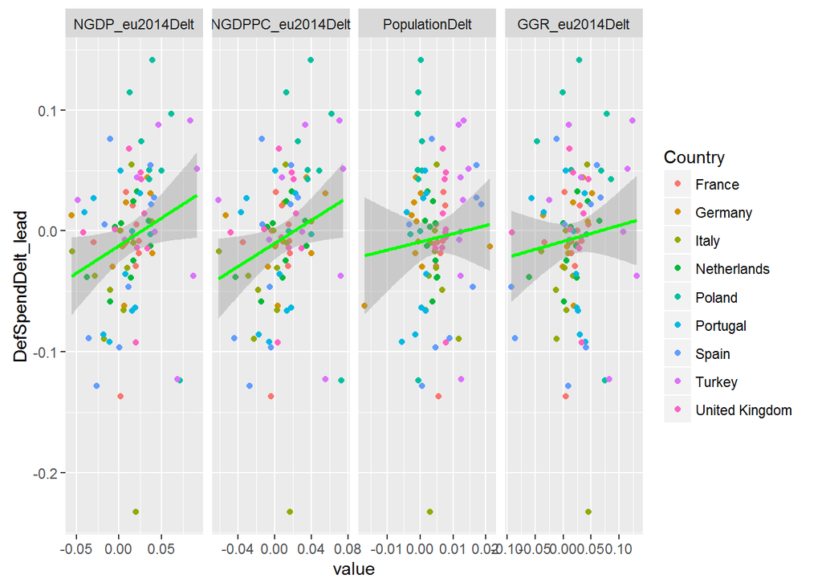

```r
MagnitudeScatter <- melt(EuropeOmnibus, measure.vars = c("NGDP_eu2014Delt",
                                           "NGDPPC_eu2014Delt",
                                           "PopulationDelt",
                                           "GGR_eu2014Delt"))


    ggplot(data=MagnitudeScatter,aes(x=value,
                            y=DefSpendDelt_lead,
                            color=Country))+geom_point()+
        facet_grid(~variable,scale="free_x")+geom_point()+stat_smooth(method = "lm", col = "green")
```

```r
reg<-2
lmMoreDef[reg]<-list(lm(log(DefSpend_lead) ~ DefSpread_lag1 + log(NGDP_eu2014), EuropeMoreDef))
lmEUldr[reg]<-list(lm(log(DefSpend_lead) ~ EUldrSpread_lag1 + log(NGDP_eu2014), EuropeEUleadership))
lmNATOess[reg]<-list(lm(log(DefSpend_lead) ~ NATOessSpread_lag1 + log(NGDP_eu2014), EuropeNATOess))
lmEU_UScls[reg]<-list(lm(log(DefSpend_lead) ~ EUcloserUSspread_lag1 + log(NGDP_eu2014), EuropeOmnibus))
nModel[reg]<-"GDP"
reg<-3
lmMoreDef[reg]<-list(lm(log(DefSpend_lead) ~ DefSpread_lag1 + log(NGDPPC_eu2014)+
                            log(Population), EuropeMoreDef))
lmEUldr[reg]<-list(lm(log(DefSpend_lead) ~ EUldrSpread_lag1 + log(NGDPPC_eu2014)+
                            log(Population), EuropeEUleadership))
lmNATOess[reg]<-list(lm(log(DefSpend_lead) ~ NATOessSpread_lag1 + log(NGDPPC_eu2014)+
                            log(Population), EuropeNATOess))
lmEU_UScls[reg]<-list(lm(log(DefSpend_lead) ~ EUcloserUSspread_lag1 + log(NGDPPC_eu2014)+
                            log(Population), EuropeEUcloserUS))
nModel[reg]<-"GDP/pop"
reg<-4
lmMoreDef[reg]<-list(lm(log(DefSpend_lead) ~ DefSpread_lag1 + log(GGR_eu2014), EuropeMoreDef))
lmEUldr[reg]<-list(lm(log(DefSpend_lead) ~ EUldrSpread_lag1 + log(GGR_eu2014), EuropeEUleadership))
lmNATOess[reg]<-list(lm(log(DefSpend_lead) ~ NATOessSpread_lag1 + log(GGR_eu2014), EuropeNATOess))
lmEU_UScls[reg]<-list(lm(log(DefSpend_lead) ~ EUcloserUSspread_lag1 + log(GGR_eu2014), EuropeEUcloserUS))
nModel[reg]<-"GGR"

screenreg(c(lmMoreDef[2:4],
               lmEUldr[2:4]
               ),
               custom.model.names=c(rep(nModel[2:4],2)),
                 stars=c(0.001,0.01,0.05,0.1),
          reorder.coef=c(1,2,7,3,4,5,6),
          groups = list("Intercept" = 1,"Polling" = 2:3,"Macroeconomic" = 4:7))
```

```
##
## ========================================================================================
##                         GDP        GDP/pop    GGR        GDP        GDP/pop    GGR
## ----------------------------------------------------------------------------------------
## Intercept
##
##     (Intercept)         16.30 ***  -5.49 ***  17.54 ***  16.76 ***  -4.75 ***  18.03 ***
##                         (0.19)     (0.75)     (0.17)     (0.26)     (0.90)     (0.24)
## Polling
##
##     DefSpread_lag1       0.77 ***   0.70 ***   0.97 ***
##                         (0.15)     (0.16)     (0.16)
##     EUldrSpread_lag1                                     -0.86 ***  -0.80 ***  -1.16 ***
##                                                          (0.22)     (0.22)     (0.22)
## Macroeconomic
##
##     log(NGDP_eu2014)     1.06 ***                         1.04 ***
##                         (0.03)                           (0.03)
##     log(NGDPPC_eu2014)              1.00 ***                         0.98 ***
##                                    (0.06)                           (0.07)
##     log(Population)                 1.08 ***                         1.07 ***
##                                    (0.04)                           (0.05)
##     log(GGR_eu2014)                            1.01 ***                         1.01 ***
##                                               (0.03)                           (0.03)
## ----------------------------------------------------------------------------------------
## R^2                      0.97       0.97       0.96       0.94       0.94       0.94
## Adj. R^2                 0.97       0.97       0.96       0.94       0.94       0.93
## Num. obs.               53         53         53         70         70         70
## RMSE                     0.23       0.22       0.24       0.25       0.24       0.25
## ========================================================================================
## *** p < 0.001, ** p < 0.01, * p < 0.05, . p < 0.1
```

```r
screenreg(c(lmNATOess[2:4],
               lmEU_UScls[2:4]),
               custom.model.names=c(rep(nModel[2:4],2)),
                 stars=c(0.001,0.01,0.05,0.1),
          reorder.coef=c(1,2,7,3,4,5,6),
          groups = list("Intercept" = 1,"Polling" = 2:3,"Macroeconomic" = 4:7))
```

```
##
## ===========================================================================================
##                            GDP        GDP/pop    GGR        GDP        GDP/pop    GGR
## -------------------------------------------------------------------------------------------
## Intercept
##
##     (Intercept)            16.42 ***  -5.68 ***  17.72 ***  16.24 ***  -4.84 ***  17.38 ***
##                            (0.23)     (0.77)     (0.22)     (0.26)     (0.98)     (0.25)
## Polling
##
##     NATOessSpread_lag1      0.10       1.00 ***   0.02
##                            (0.19)     (0.21)     (0.22)
##     EUcloserUSspread_lag1                                   -0.16      -0.58 *    -0.07
##                                                             (0.19)     (0.24)     (0.21)
## Macroeconomic
##
##     log(NGDP_eu2014)        1.02 ***                         1.04 ***
##                            (0.03)                           (0.04)
##     log(NGDPPC_eu2014)                 0.75 ***                         0.79 ***
##                                       (0.05)                           (0.09)
##     log(Population)                    1.21 ***                         1.15 ***
##                                       (0.04)                           (0.05)
##     log(GGR_eu2014)                               0.96 ***                         1.00 ***
##                                                  (0.04)                           (0.04)
## -------------------------------------------------------------------------------------------
## R^2                         0.92       0.95       0.89       0.93       0.94       0.91
## Adj. R^2                    0.92       0.94       0.89       0.92       0.93       0.91
## Num. obs.                  87         87         87         64         64         64
## RMSE                        0.27       0.22       0.32       0.27       0.26       0.30
## ===========================================================================================
## *** p < 0.001, ** p < 0.01, * p < 0.05, . p < 0.1
```

### 2.2.2 Government Debt, Deficit / Surplus

```r
corrdisp<-rcorr(as.matrix(subset(EuropeOmnibus, select=c(DefSpread_lag1,
                                               EUldrSpread_lag1,
                                               NATOessSpread_lag1,
                                               EUcloserUSspread_lag1,
                                               NGDPPC_eu2014,
                                               Population,
                                               Debt_NGDP,
                                               EUdebt_NGDP
                                               ))))


corrdisp[[1]][,7:8]
```

```
##                          Debt_NGDP EUdebt_NGDP
## DefSpread_lag1        -0.499016494 -0.21427460
## EUldrSpread_lag1       0.369348854 -0.16483486
## NATOessSpread_lag1     0.160702080 -0.02174546
## EUcloserUSspread_lag1  0.085260175  0.49662474
## NGDPPC_eu2014          0.240425602 -0.02136463
## Population            -0.007112417  0.01664566
## Debt_NGDP              1.000000000  0.43271878
## EUdebt_NGDP            0.432718784  1.00000000
```

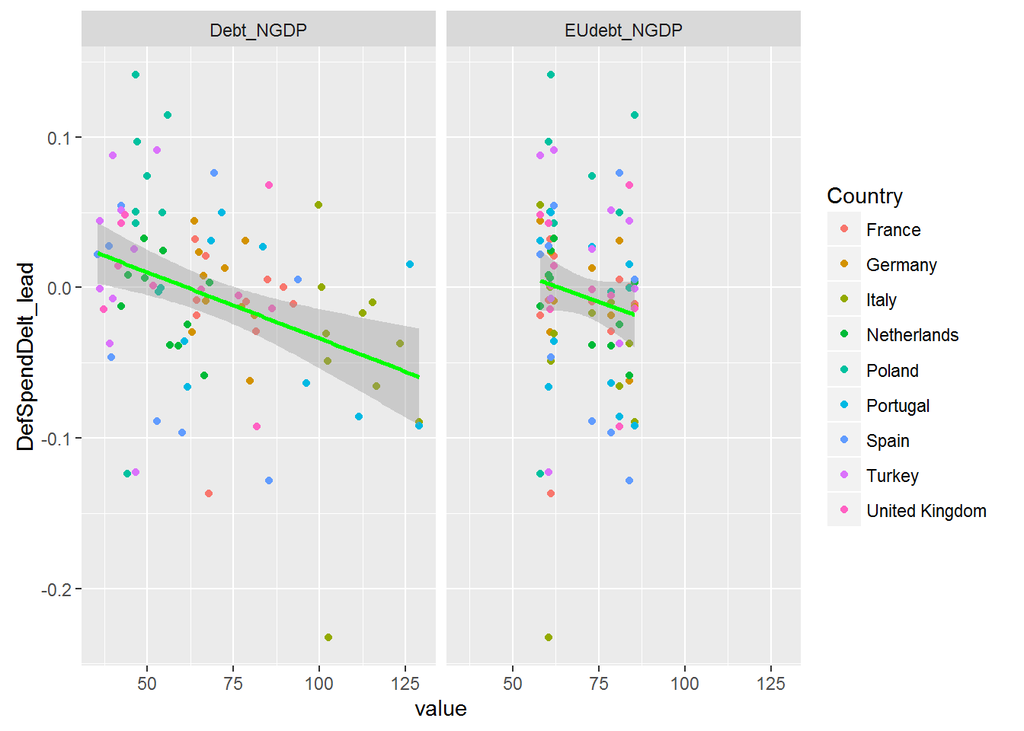

```r
DebtScatter <- melt(EuropeOmnibus, measure.vars = c("Debt_NGDP",
                                           "EUdebt_NGDP"))

    ggplot(data=DebtScatter,aes(x=value,
                            y=DefSpendDelt_lead,
                            color=Country))+geom_point()+
        facet_wrap(~variable)+geom_point()+stat_smooth(method = "lm", col = "green")
```

```r
reg<-5
lmMoreDef[reg]<-list(lm(log(DefSpend_lead) ~ DefSpread_lag1 + log(NGDPPC_eu2014)+
                            log(Population)+Debt_NGDP, EuropeMoreDef))
lmEUldr[reg]<-list(lm(log(DefSpend_lead) ~ EUldrSpread_lag1 + log(NGDPPC_eu2014)+
                            log(Population)+Debt_NGDP, EuropeEUleadership))
lmNATOess[reg]<-list(lm(log(DefSpend_lead) ~ NATOessSpread_lag1 + log(NGDPPC_eu2014)+
                            log(Population)+Debt_NGDP, EuropeNATOess))
lmEU_UScls[reg]<-list(lm(log(DefSpend_lead) ~ EUcloserUSspread_lag1+ log(NGDPPC_eu2014)+
                            log(Population)+Debt_NGDP, EuropeEUcloserUS))
nModel[reg]<-"GGXWDG"

reg<-6
lmMoreDef[reg]<-list(lm(log(DefSpend_lead) ~ DefSpread_lag1 + log(NGDPPC_eu2014)+
                            log(Population)+Debt_NGDP+EUdebt_NGDP, EuropeMoreDef))
lmEUldr[reg]<-list(lm(log(DefSpend_lead) ~ EUldrSpread_lag1 + log(NGDPPC_eu2014)+
                            log(Population)+Debt_NGDP+EUdebt_NGDP, EuropeEUleadership))
lmNATOess[reg]<-list(lm(log(DefSpend_lead) ~ NATOessSpread_lag1 + log(NGDPPC_eu2014)+
                            log(Population)+Debt_NGDP+EUdebt_NGDP, EuropeNATOess))
lmEU_UScls[reg]<-list(lm(log(DefSpend_lead) ~ EUcloserUSspread_lag1+ log(NGDPPC_eu2014)+
                            log(Population)+Debt_NGDP+EUdebt_NGDP, EuropeEUcloserUS))
nModel[reg]<-"+EUdebt_NGDP"

screenreg(c(lmMoreDef[c(3,5:6)],
               lmEUldr[c(3,5:6)]),
               custom.model.names=c(rep(nModel[c(3,5:6)],2)),
                 stars=c(0.001,0.01,0.05,0.1),
          reorder.coef=c(1,2,7,3,4,5,6),
          groups = list("Intercept" = 1,"Polling" = 2:3,"Macroeconomic" = 4:7))
```

```
##
## ==============================================================================================
##                         GDP/pop    GGXWDG     +EUdebt_NGDP  GDP/pop    GGXWDG     +EUdebt_NGDP
## ----------------------------------------------------------------------------------------------
## Intercept
##
##     (Intercept)         -5.49 ***  -5.59 ***  -4.77 ***     -4.75 ***  -4.74 ***  -4.06 ***
##                         (0.75)     (0.77)     (0.82)        (0.90)     (0.89)     (0.90)
## Polling
##
##     DefSpread_lag1       0.70 ***   0.66 ***   0.61 ***
##                         (0.16)     (0.17)     (0.17)
##     EUldrSpread_lag1                                        -0.80 ***  -0.78 ***  -0.96 ***
##                                                             (0.22)     (0.22)     (0.22)
## Macroeconomic
##
##     log(NGDPPC_eu2014)   1.00 ***   1.00 ***   0.97 ***      0.98 ***   0.99 ***   0.99 ***
##                         (0.06)     (0.06)     (0.06)        (0.07)     (0.07)     (0.06)
##     log(Population)      1.08 ***   1.09 ***   1.09 ***      1.07 ***   1.07 ***   1.06 ***
##                         (0.04)     (0.04)     (0.04)        (0.05)     (0.05)     (0.04)
##     Debt_NGDP                      -0.00       0.00                    -0.00 .    -0.00
##                                    (0.00)     (0.00)                   (0.00)     (0.00)
##     EUdebt_NGDP                               -0.01 *                             -0.01 *
##                                               (0.00)                              (0.00)
## ----------------------------------------------------------------------------------------------
## R^2                      0.97       0.97       0.97          0.94       0.94       0.95
## Adj. R^2                 0.97       0.97       0.97          0.94       0.94       0.94
## Num. obs.               53         53         53            70         70         70
## RMSE                     0.22       0.22       0.21          0.24       0.24       0.23
## ==============================================================================================
## *** p < 0.001, ** p < 0.01, * p < 0.05, . p < 0.1
```

```r
                        # , "Security"=6,, "Parliamentary"=8:11))



screenreg(c(lmNATOess[c(3,5:6)],
               lmEU_UScls[c(3,5:6)]),
               custom.model.names=c(rep(nModel[c(3,5:6)],2)),
                 stars=c(0.001,0.01,0.05,0.1),
          reorder.coef=c(1,2,7,3,4,5,6),
          groups = list("Intercept" = 1,"Polling" = 2:3,"Macroeconomic" = 4:7))
```

```
##
## =================================================================================================
##                            GDP/pop    GGXWDG     +EUdebt_NGDP  GDP/pop    GGXWDG     +EUdebt_NGDP
## -------------------------------------------------------------------------------------------------
## Intercept
##
##     (Intercept)            -5.68 ***  -5.72 ***  -5.43 ***     -4.84 ***  -4.87 ***  -5.01 ***
##                            (0.77)     (0.76)     (0.78)        (0.98)     (0.98)     (1.00)
## Polling
##
##     NATOessSpread_lag1      1.00 ***   0.97 ***   0.97 ***
##                            (0.21)     (0.21)     (0.21)
##     EUcloserUSspread_lag1                                      -0.58 *    -0.53 *    -0.67 *
##                                                                (0.24)     (0.24)     (0.32)
## Macroeconomic
##
##     log(NGDPPC_eu2014)      0.75 ***   0.78 ***   0.77 ***      0.79 ***   0.81 ***   0.78 ***
##                            (0.05)     (0.05)     (0.05)        (0.09)     (0.10)     (0.11)
##     log(Population)         1.21 ***   1.21 ***   1.21 ***      1.15 ***   1.15 ***   1.16 ***
##                            (0.04)     (0.04)     (0.04)        (0.05)     (0.05)     (0.06)
##     Debt_NGDP                         -0.00 .    -0.00                    -0.00      -0.00
##                                       (0.00)     (0.00)                   (0.00)     (0.00)
##     EUdebt_NGDP                                  -0.00                                0.00
##                                                  (0.00)                              (0.00)
## -------------------------------------------------------------------------------------------------
## R^2                         0.95       0.95       0.95          0.94       0.94       0.94
## Adj. R^2                    0.94       0.94       0.95          0.93       0.93       0.93
## Num. obs.                  87         87         87            64         64         64
## RMSE                        0.22       0.22       0.22          0.26       0.26       0.26
## =================================================================================================
## *** p < 0.001, ** p < 0.01, * p < 0.05, . p < 0.1
```

```r
                        # , "Security"=6,, "Parliamentary"=8:11))
```

```r
corrdisp<-rcorr(as.matrix(subset(EuropeOmnibus, select=c(DefSpread_lag1,
                                               EUldrSpread_lag1,
                                               NATOessSpread_lag1,
                                               EUcloserUSspread_lag1,
                                               NGDPPC_eu2014,
                                               Population,
                                               Debt_NGDP,
                                               EUdebt_NGDP,
                                               SDfc_NGDP,
                                               Dfc_NGDP))))


corrdisp[[1]][,9:10]
```

```
##                         SDfc_NGDP    Dfc_NGDP
## DefSpread_lag1        -0.60134822 -0.30318573
## EUldrSpread_lag1       0.17401880  0.04724505
## NATOessSpread_lag1    -0.04194754 -0.27171257
## EUcloserUSspread_lag1 -0.24377665 -0.26671907
## NGDPPC_eu2014          0.28314301  0.10726511
## Population             0.08580177  0.19892223
## Debt_NGDP             -0.03916647 -0.29067272
## EUdebt_NGDP           -0.09360801 -0.39571404
## SDfc_NGDP              1.00000000  0.82525855
## Dfc_NGDP               0.82525855  1.00000000
```

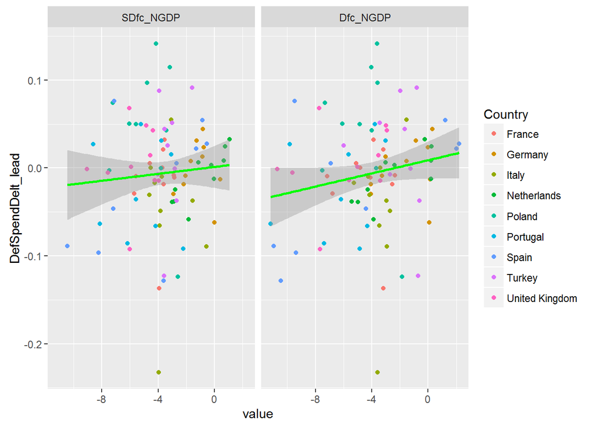

```r
BalanceScatter <- melt(EuropeOmnibus, measure.vars = c("SDfc_NGDP",
                                           "Dfc_NGDP"))


    ggplot(data=BalanceScatter,aes(x=value,
                            y=DefSpendDelt_lead,
                            color=Country))+geom_point()+
        facet_wrap(~variable)+geom_point()+stat_smooth(method = "lm", col = "green")
```

[output not shown]

[figure not shown]

```r
    BalanceLine <- melt(EuropeOmnibus, measure.vars = c("NGDP_eu2014",
"SDfc_NGDP",
                                           "Dfc_NGDP",
                                           "DefSpend_lead"))

    BalanceLine$value[BalanceLine$variable %in% c("NGDP_eu2014","DefSpend_lead")]<-
        log(BalanceLine$value[BalanceLine$variable %in% c("NGDP_eu2014","DefSpend_lead")])
    ggplot(data=BalanceLine,aes(x=Year,
                            y=value,
                            color=variable))+geom_line()+facet_grid(variable~Country,scale="free_y")
```

```r
reg<-7
lmMoreDef[reg]<-list(lm(log(DefSpend_lead) ~ DefSpread_lag1 + log(NGDPPC_eu2014)+
                            log(Population)+Debt_NGDP+EUdebt_NGDP+SDfc_NGDP, EuropeMoreDef))
lmEUldr[reg]<-list(lm(log(DefSpend_lead) ~ EUldrSpread_lag1 + log(NGDPPC_eu2014)+
                            log(Population)+Debt_NGDP+EUdebt_NGDP+SDfc_NGDP, EuropeEUleadership))
lmNATOess[reg]<-list(lm(log(DefSpend_lead) ~ NATOessSpread_lag1 + log(NGDPPC_eu2014)+
                            log(Population)+Debt_NGDP+EUdebt_NGDP+SDfc_NGDP, EuropeNATOess))
lmEU_UScls[reg]<-list(lm(log(DefSpend_lead) ~ EUcloserUSspread_lag1+ log(NGDPPC_eu2014)+
                            log(Population)+Debt_NGDP+EUdebt_NGDP+SDfc_NGDP, EuropeEUcloserUS))
nModel[reg]<-"GGSB"
reg<-8
lmMoreDef[reg]<-list(lm(log(DefSpend_lead) ~ DefSpread_lag1 + log(NGDPPC_eu2014)+
                            log(Population)+Debt_NGDP+EUdebt_NGDP+Dfc_NGDP, EuropeMoreDef))
lmEUldr[reg]<-list(lm(log(DefSpend_lead) ~ EUldrSpread_lag1 + log(NGDPPC_eu2014)+
                            log(Population)+Debt_NGDP+EUdebt_NGDP+Dfc_NGDP, EuropeEUleadership))
lmNATOess[reg]<-list(lm(log(DefSpend_lead) ~ NATOessSpread_lag1 + log(NGDPPC_eu2014)+
                            log(Population)+Debt_NGDP+EUdebt_NGDP+Dfc_NGDP, EuropeNATOess))
lmEU_UScls[reg]<-list(lm(log(DefSpend_lead) ~ EUcloserUSspread_lag1+ log(NGDPPC_eu2014)+
                            log(Population)+Debt_NGDP+EUdebt_NGDP+Dfc_NGDP, EuropeEUcloserUS))
nModel[reg]<-"GGXCNL"


screenreg(c(lmMoreDef[c(6:8)],
               lmEUldr[c(6:8)]),
               custom.model.names=c(rep(nModel[c(6:8)],2)),
                 stars=c(0.001,0.01,0.05,0.1),
          reorder.coef=c(1,2,9,3,4,5,6,7,8),
          groups = list("Intercept" = 1,"Polling" = 2:3,"Macroeconomic" = 4:9))
```

```
##
## ==============================================================================================
##                         +EUdebt_NGDP  GGSB       GGXCNL     +EUdebt_NGDP  GGSB       GGXCNL
## ----------------------------------------------------------------------------------------------
## Intercept
##
##     (Intercept)         -4.77 ***     -4.73 ***  -4.59 ***  -4.06 ***     -4.44 ***  -4.20 ***
##                         (0.82)        (0.87)     (0.84)     (0.90)        (0.96)     (0.95)
## Polling
##
##     DefSpread_lag1       0.61 ***      0.63 **    0.69 ***
##                         (0.17)        (0.22)     (0.19)
##     EUldrSpread_lag1                                        -0.96 ***     -0.83 **   -0.91 ***
##                                                             (0.22)        (0.25)     (0.25)
## Macroeconomic
##
##     log(NGDPPC_eu2014)   0.97 ***      0.97 ***   0.97 ***   0.99 ***      1.02 ***   1.00 ***
##                         (0.06)        (0.06)     (0.06)     (0.06)        (0.07)     (0.07)
##     log(Population)      1.09 ***      1.08 ***   1.07 ***   1.06 ***      1.06 ***   1.07 ***
##                         (0.04)        (0.04)     (0.04)     (0.04)        (0.04)     (0.04)
##     Debt_NGDP            0.00          0.00       0.00      -0.00         -0.00      -0.00
##                         (0.00)        (0.00)     (0.00)     (0.00)        (0.00)     (0.00)
##     EUdebt_NGDP         -0.01 *       -0.01 *    -0.01 *    -0.01 *       -0.01 *    -0.01 *
##                         (0.00)        (0.00)     (0.00)     (0.00)        (0.00)     (0.00)
##     SDfc_NGDP                          0.00                               -0.01
##                                       (0.02)                              (0.01)
##     Dfc_NGDP                                      0.01                               -0.01
##                                                  (0.01)                              (0.01)
## ----------------------------------------------------------------------------------------------
## R^2                      0.97          0.97       0.97       0.95          0.95       0.95
## Adj. R^2                 0.97          0.97       0.97       0.94          0.94       0.94
## Num. obs.               53            53         53         70            70         70
## RMSE                     0.21          0.22       0.21       0.23          0.23       0.23
## ==============================================================================================
## *** p < 0.001, ** p < 0.01, * p < 0.05, . p < 0.1
```

```r
                        # , "Security"=6,, "Parliamentary"=8:11))



screenreg(c(lmNATOess[c(6:8)],
               lmEU_UScls[c(6:8)]),
               custom.model.names=c(rep(nModel[c(6:8)],2)),
                 stars=c(0.001,0.01,0.05,0.1),
          reorder.coef=c(1,2,9,3,4,5,6,7,8),
          groups = list("Intercept" = 1,"Polling" = 2:3,"Macroeconomic" = 4:9))
```

```
##
## =================================================================================================
##                            +EUdebt_NGDP  GGSB       GGXCNL     +EUdebt_NGDP  GGSB       GGXCNL
## -------------------------------------------------------------------------------------------------
## Intercept
##
##     (Intercept)            -5.43 ***     -5.66 ***  -5.50 ***  -5.01 ***     -5.68 ***  -5.41 ***
##                            (0.78)        (0.77)     (0.78)     (1.00)        (0.96)     (0.99)
## Polling
##
##     NATOessSpread_lag1      0.97 ***      0.88 ***   0.90 ***
##                            (0.21)        (0.21)     (0.23)
##     EUcloserUSspread_lag1                                      -0.67 *       -0.66 *    -0.65 *
##                                                                (0.32)        (0.30)     (0.31)
## Macroeconomic
##
##     log(NGDPPC_eu2014)      0.77 ***      0.80 ***   0.78 ***   0.78 ***      0.86 ***   0.82 ***
##                            (0.05)        (0.05)     (0.06)     (0.11)        (0.10)     (0.11)
##     log(Population)         1.21 ***      1.20 ***   1.21 ***   1.16 ***      1.16 ***   1.17 ***
##                            (0.04)        (0.04)     (0.04)     (0.06)        (0.05)     (0.06)
##     Debt_NGDP              -0.00         -0.00      -0.00      -0.00         -0.00      -0.00
##                            (0.00)        (0.00)     (0.00)     (0.00)        (0.00)     (0.00)
##     EUdebt_NGDP            -0.00         -0.00      -0.00 .     0.00          0.00       0.00
##                            (0.00)        (0.00)     (0.00)     (0.00)        (0.00)     (0.00)
##     SDfc_NGDP                            -0.02 *                             -0.04 **
##                                          (0.01)                              (0.01)
##     Dfc_NGDP                                        -0.01                               -0.02 *
##                                                     (0.01)                              (0.01)
## -------------------------------------------------------------------------------------------------
## R^2                         0.95          0.95       0.95       0.94          0.95       0.94
## Adj. R^2                    0.95          0.95       0.95       0.93          0.94       0.94
## Num. obs.                  87            87         87         64            64         64
## RMSE                        0.22          0.22       0.22       0.26          0.24       0.25
## =================================================================================================
## *** p < 0.001, ** p < 0.01, * p < 0.05, . p < 0.1
```

```r
                        # , "Security"=6,, "Parliamentary"=8:11))
```

GGXCNL, the country’s actual balance sheet rather than the strucutural one, seems like the better fit of the two. The negatives for some of the variables contradict what you would expect from the literature and worse for GGSB. In those cases, it may be acting as a hidden variable reflecting the government’s willingness to carry deficits. We are adding GGXCNL, as it better reflects the scatter plot and measures contained in the Treaty of Maastricht.

## 2.3 Security Environment Controls

### 2.3.1 Militarizied disputes and support for UN operations.

```r
corrdisp<-rcorr(as.matrix(subset(EuropeOmnibus, select=c(DefSpread_lag1,
                                               EUldrSpread_lag1,
                                               NATOessSpread_lag1,
                                               EUcloserUSspread_lag1,
                                               NGDPPC_eu2014,
                                               Population,
                                               Debt_NGDP,
                                               EUdebt_NGDP,
                                               Dfc_NGDP,
                                               IntlCnf,
                                               UNmilitaryPMil))))

corrdisp[[1]][,10:11]
```

```
##                          IntlCnf UNmilitaryPMil
## DefSpread_lag1         0.1802364     0.21996827
## EUldrSpread_lag1      -0.4953116     0.13215487
## NATOessSpread_lag1    -0.1876141    -0.33854276
## EUcloserUSspread_lag1        NaN     0.18843205
## NGDPPC_eu2014         -0.4611041    -0.02431032
## Population             0.1699331     0.06316303
## Debt_NGDP             -0.2622937     0.31262431
## EUdebt_NGDP           -0.1890392    -0.09469501
## Dfc_NGDP               0.1227731    -0.16116747
## IntlCnf                1.0000000    -0.10297546
## UNmilitaryPMil        -0.1029755     1.00000000
```

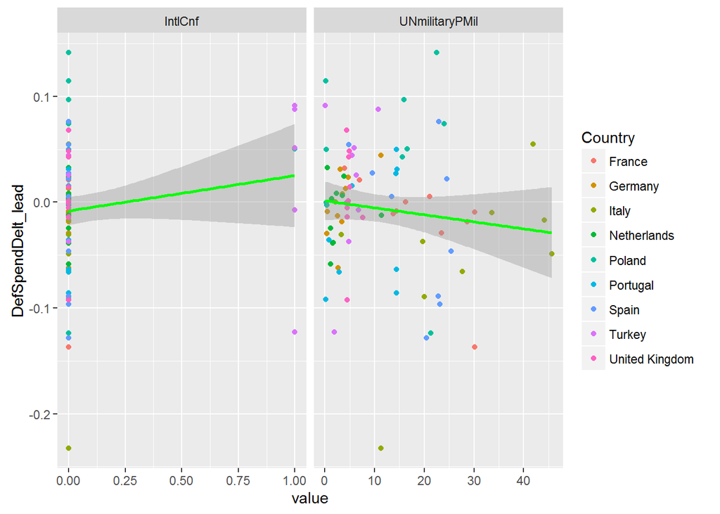

```r
ConflictScatter <- melt(EuropeOmnibus, measure.vars = c("IntlCnf",
                                           "UNmilitaryPMil"))


    ggplot(data=ConflictScatter ,aes(x=value,
                            y=DefSpendDelt_lead,
                            color=Country))+geom_point()+
        facet_grid(~variable,scale="free_x")+geom_point()+stat_smooth(method = "lm", col = "green")
```

```r
reg<-9
lmMoreDef[reg]<-list(lm(log(DefSpend_lead) ~ DefSpread_lag1 + log(NGDPPC_eu2014)+
                            log(Population)+Debt_NGDP+EUdebt_NGDP+
                            Dfc_NGDP+IntlCnf, EuropeMoreDef))
lmEUldr[reg]<-list(lm(log(DefSpend_lead) ~ EUldrSpread_lag1 + log(NGDPPC_eu2014)+
                          log(Population)+Debt_NGDP+EUdebt_NGDP+
                          Dfc_NGDP+IntlCnf, EuropeEUleadership))
lmNATOess[reg]<-list(lm(log(DefSpend_lead) ~ NATOessSpread_lag1 + log(NGDPPC_eu2014)+
                            log(Population)+Debt_NGDP+EUdebt_NGDP+
                            Dfc_NGDP+IntlCnf, EuropeNATOess))
lmEU_UScls[reg]<-list(lm(log(DefSpend_lead) ~ EUcloserUSspread_lag1+ log(NGDPPC_eu2014)+
                             log(Population)+Debt_NGDP+EUdebt_NGDP+
                             Dfc_NGDP+IntlCnf, EuropeEUcloserUS))
nModel[reg]<-"IntlCnf"
reg<-10
lmMoreDef[reg]<-list(lm(log(DefSpend_lead) ~ DefSpread_lag1 +
                            log(NGDPPC_eu2014)+log(Population)+Debt_NGDP+
                            EUdebt_NGDP+Dfc_NGDP+UNmilitaryPMil,
                        EuropeMoreDef))
lmEUldr[reg]<-list(lm(log(DefSpend_lead) ~ EUldrSpread_lag1 +
                          log(NGDPPC_eu2014)+log(Population)+
                          Debt_NGDP+EUdebt_NGDP+Dfc_NGDP+UNmilitaryPMil,
                      EuropeEUleadership))
lmNATOess[reg]<-list(lm(log(DefSpend_lead) ~ NATOessSpread_lag1 + log(NGDPPC_eu2014)+
                            log(Population)+Debt_NGDP+EUdebt_NGDP+Dfc_NGDP+UNmilitaryPMil,
                        EuropeNATOess))
lmEU_UScls[reg]<-list(lm(log(DefSpend_lead) ~ EUcloserUSspread_lag1+
                             log(NGDPPC_eu2014)+log(Population)+
                             Debt_NGDP+EUdebt_NGDP+Dfc_NGDP+UNmilitaryPMil,
                         EuropeEUcloserUS))
nModel[reg]<-"UNmil"


screenreg(c(lmMoreDef[c(6,9:10)],
               lmEUldr[c(6,9:10)]),
               custom.model.names=c(rep(nModel[c(7,9:10)],2)),
                 stars=c(0.001,0.01,0.05,0.1),
                    reorder.coef=c(1,2,10,3,4,5,6,7,8,9),
          groups = list("Intercept" = 1,"Polling" = 2:3,"Macroeconomic" = 4:8,"Security"=9:10))
```

```
##
## ========================================================================================
##                         GGSB       IntlCnf    UNmil      GGSB       IntlCnf    UNmil
## ----------------------------------------------------------------------------------------
## Intercept
##
##     (Intercept)         -4.77 ***  -4.66 ***  -4.07 ***  -4.06 ***  -4.24 ***  -4.12 ***
##                         (0.82)     (0.89)     (0.90)     (0.90)     (0.98)     (0.86)
## Polling
##
##     DefSpread_lag1       0.61 ***   0.69 ***   0.71 ***
##                         (0.17)     (0.19)     (0.19)
##     EUldrSpread_lag1                                     -0.96 ***  -0.91 ***  -0.99 ***
##                                                          (0.22)     (0.25)     (0.23)
## Macroeconomic
##
##     log(NGDPPC_eu2014)   0.97 ***   0.98 ***   0.96 ***   0.99 ***   1.00 ***   0.96 ***
##                         (0.06)     (0.07)     (0.06)     (0.06)     (0.07)     (0.06)
##     log(Population)      1.09 ***   1.07 ***   1.05 ***   1.06 ***   1.06 ***   1.11 ***
##                         (0.04)     (0.04)     (0.04)     (0.04)     (0.05)     (0.04)
##     Debt_NGDP            0.00       0.00       0.00      -0.00      -0.00       0.00
##                         (0.00)     (0.00)     (0.00)     (0.00)     (0.00)     (0.00)
##     EUdebt_NGDP         -0.01 *    -0.01 *    -0.01 *    -0.01 *    -0.01 *    -0.01 ***
##                         (0.00)     (0.00)     (0.00)     (0.00)     (0.00)     (0.00)
##     Dfc_NGDP                        0.01       0.01                 -0.01      -0.01
##                                    (0.01)     (0.01)                (0.01)     (0.01)
## Security
##
##     IntlCnf                         0.05                             0.05
##                                    (0.18)                           (0.25)
##     UNmilitaryPMil                            -0.00                            -0.01 ***
##                                               (0.00)                           (0.00)
## ----------------------------------------------------------------------------------------
## R^2                      0.97       0.97       0.97       0.95       0.95       0.96
## Adj. R^2                 0.97       0.97       0.97       0.94       0.94       0.95
## Num. obs.               53         53         53         70         70         70
## RMSE                     0.21       0.22       0.21       0.23       0.23       0.21
## ========================================================================================
## *** p < 0.001, ** p < 0.01, * p < 0.05, . p < 0.1
```

```r
screenreg(c(lmNATOess[c(6,9:10)],
               lmEU_UScls[c(6,9:10)]),
               custom.model.names=c(rep(nModel[c(7,9:10)],2)),
                 stars=c(0.001,0.01,0.05,0.1),
                    reorder.coef=c(1,2,10,3,4,5,6,7,8,9),
          groups = list("Intercept" = 1,"Polling" = 2:3,"Macroeconomic" = 4:8,"Security"=9:10))
```

```
##
## ===========================================================================================
##                            GGSB       IntlCnf    UNmil      GGSB       IntlCnf    UNmil
## -------------------------------------------------------------------------------------------
## Intercept
##
##     (Intercept)            -5.43 ***  -5.38 ***  -5.50 ***  -5.01 ***  -5.41 ***  -5.54 ***
##                            (0.78)     (0.81)     (0.78)     (1.00)     (0.99)     (0.97)
## Polling
##
##     NATOessSpread_lag1      0.97 ***   0.96 ***   0.71 *
##                            (0.21)     (0.24)     (0.27)
##     EUcloserUSspread_lag1                                   -0.67 *    -0.65 *    -0.44
##                                                             (0.32)     (0.31)     (0.32)
## Macroeconomic
##
##     log(NGDPPC_eu2014)      0.77 ***   0.76 ***   0.81 ***   0.78 ***   0.82 ***   0.85 ***
##                            (0.05)     (0.07)     (0.06)     (0.11)     (0.11)     (0.10)
##     log(Population)         1.21 ***   1.22 ***   1.20 ***   1.16 ***   1.17 ***   1.18 ***
##                            (0.04)     (0.05)     (0.04)     (0.06)     (0.06)     (0.06)
##     Debt_NGDP              -0.00      -0.00      -0.00      -0.00      -0.00      -0.00
##                            (0.00)     (0.00)     (0.00)     (0.00)     (0.00)     (0.00)
##     EUdebt_NGDP            -0.00      -0.00 .    -0.01 *     0.00       0.00      -0.01
##                            (0.00)     (0.00)     (0.00)     (0.00)     (0.00)     (0.01)
##     Dfc_NGDP                          -0.01      -0.01                 -0.02 *    -0.03 *
##                                       (0.01)     (0.01)                (0.01)     (0.01)
## Security
##
##     IntlCnf                           -0.08
##                                       (0.13)
##     UNmilitaryPMil                               -0.00                            -0.01 .
##                                                  (0.00)                           (0.00)
## -------------------------------------------------------------------------------------------
## R^2                         0.95       0.95       0.95       0.94       0.94       0.95
## Adj. R^2                    0.95       0.95       0.95       0.93       0.94       0.94
## Num. obs.                  87         87         87         64         64         64
## RMSE                        0.22       0.22       0.22       0.26       0.25       0.24
## ===========================================================================================
## *** p < 0.001, ** p < 0.01, * p < 0.05, . p < 0.1
```

```r
subset(EuropeOmnibus,IntlCnf==1)[,1:2]
```

```
##      Country Year
## 1159  Poland 2003
## 2621  Turkey 2005
## 2622  Turkey 2006
## 2623  Turkey 2007
## 2624  Turkey 2008
## 2626  Turkey 2010
```

The direction of the UN troops + experts per million in population was surprising, as we had intuited that it may build support for spending. However, it appears to be a non-spurious results as it does align with the scatter plot and doesn’t specifically contradict past literature. Leaving it in as it is significant in some cases. International conflict is actually a challenging variable as it’s only true in 6 instances, 5 of which being Turkey. Participation in operations in Afghanistan does not qualify. Given the limited relevance and the risk that it’s a dummy variable for Turkey, it will be left out.

On the other hand UN military, it does seem to lead to a Cook’s distance violation for More Defense. We’ll track that going forward.

### 2.3.2 Terrorist Attacks

```r
corrdisp<-rcorr(as.matrix(subset(EuropeOmnibus, select=c(DefSpread_lag1,
                                               EUldrSpread_lag1,
                                               NATOessSpread_lag1,
                                               EUcloserUSspread_lag1,
                                               NGDPPC_eu2014,
                                               Population,
                                               Debt_NGDP,
                                               EUdebt_NGDP,
                                               Dfc_NGDP,
                                               UNmilitaryPMil,
                                               DomAt,
                                               IntAt
                                               ))))

corrdisp[[1]][,11:12]
```

```
##                             DomAt       IntAt
## DefSpread_lag1         0.09490673  0.01919860
## EUldrSpread_lag1      -0.54677147  0.01659073
## NATOessSpread_lag1    -0.40822029  0.04763477
## EUcloserUSspread_lag1  0.05711119  0.03589927
## NGDPPC_eu2014         -0.34070948  0.21139537
## Population             0.21265993  0.26642269
## Debt_NGDP             -0.28249747  0.07283413
## EUdebt_NGDP            0.08323520  0.10442979
## Dfc_NGDP               0.19904813 -0.03848682
## UNmilitaryPMil        -0.07615472 -0.03287115
## DomAt                  1.00000000 -0.06705735
## IntAt                 -0.06705735  1.00000000
```

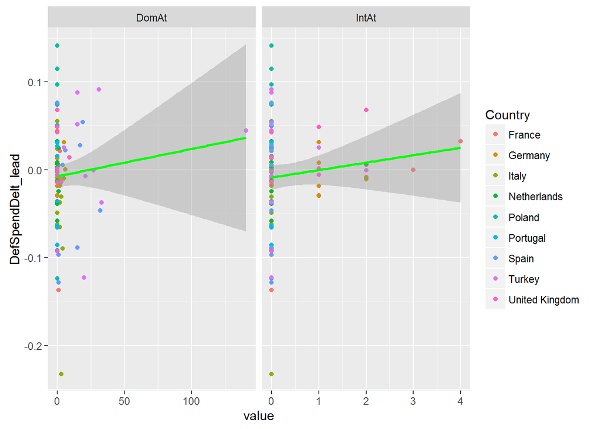

```r
TerrorismScatter <- melt(EuropeOmnibus, measure.vars = c("DomAt",
                                           "IntAt"))


    ggplot(data=TerrorismScatter,aes(x=value,
                            y=DefSpendDelt_lead,
                            color=Country))+geom_point()+
        facet_grid(~variable,scale="free_x")+geom_point()+stat_smooth(method = "lm", col = "green")
```

```r
reg<-11
lmMoreDef[reg]<-list(lm(log(DefSpend_lead) ~ DefSpread_lag1 + log(NGDPPC_eu2014)+
                            log(Population)+Debt_NGDP+EUdebt_NGDP+Dfc_NGDP+UNmilitaryPMil+DomAt, EuropeMoreDef))
lmEUldr[reg]<-list(lm(log(DefSpend_lead) ~ EUldrSpread_lag1 + log(NGDPPC_eu2014)+
                            log(Population)+Debt_NGDP+EUdebt_NGDP+Dfc_NGDP+UNmilitaryPMil +DomAt,
                      EuropeEUleadership))
lmNATOess[reg]<-list(lm(log(DefSpend_lead) ~ NATOessSpread_lag1 + log(NGDPPC_eu2014)+
                            log(Population)+Debt_NGDP+EUdebt_NGDP+Dfc_NGDP+UNmilitaryPMil +DomAt,
                        EuropeNATOess))
lmEU_UScls[reg]<-list(lm(log(DefSpend_lead) ~ EUcloserUSspread_lag1+ log(NGDPPC_eu2014)+
                            log(Population)+Debt_NGDP+EUdebt_NGDP+Dfc_NGDP+UNmilitaryPMil +DomAt,
                         EuropeOmnibus))
nModel[reg]<-"DomAt"
reg<-12
lmMoreDef[reg]<-list(lm(log(DefSpend_lead) ~ DefSpread_lag1 + log(NGDPPC_eu2014)+
                            log(Population)+Debt_NGDP+EUdebt_NGDP+Dfc_NGDP+UNmilitaryPMil+IntAt, EuropeMoreDef))
lmEUldr[reg]<-list(lm(log(DefSpend_lead) ~ EUldrSpread_lag1 + log(NGDPPC_eu2014)+
                            log(Population)+Debt_NGDP+EUdebt_NGDP+Dfc_NGDP+UNmilitaryPMil+IntAt, EuropeEUleadership))
lmNATOess[reg]<-list(lm(log(DefSpend_lead) ~ NATOessSpread_lag1 + log(NGDPPC_eu2014)+
                            log(Population)+Debt_NGDP+EUdebt_NGDP+Dfc_NGDP+UNmilitaryPMil+IntAt, EuropeNATOess))
lmEU_UScls[reg]<-list(lm(log(DefSpend_lead) ~ EUcloserUSspread_lag1+ log(NGDPPC_eu2014)+
                            log(Population)+Debt_NGDP+EUdebt_NGDP+Dfc_NGDP+UNmilitaryPMil+IntAt,
                         EuropeEUcloserUS))
nModel[reg]<-"IntAt"


screenreg(c(lmMoreDef[c(10:12)],
               lmEUldr[c(10:12)]),
               custom.model.names=c(rep(nModel[c(10:12)],2)),
                 stars=c(0.001,0.01,0.05,0.1),
        reorder.coef=c(1,2,11,3,4,5,6,7,8,9,10),
          groups = list("Intercept" = 1,"Polling" = 2:3,"Macroeconomic" = 4:8,"Security"=9:11))
```

```
##
## ========================================================================================
##                         UNmil      DomAt      IntAt      UNmil      DomAt      IntAt
## ----------------------------------------------------------------------------------------
## Intercept
##
##     (Intercept)         -4.07 ***  -4.07 ***  -3.63 ***  -4.12 ***  -4.30 ***  -3.03 ***
##                         (0.90)     (0.91)     (0.87)     (0.86)     (0.80)     (0.84)
## Polling
##
##     DefSpread_lag1       0.71 ***   0.71 ***   0.72 ***
##                         (0.19)     (0.19)     (0.18)
##     EUldrSpread_lag1                                     -0.99 ***  -1.00 ***  -1.06 ***
##                                                          (0.23)     (0.21)     (0.21)
## Macroeconomic
##
##     log(NGDPPC_eu2014)   0.96 ***   0.96 ***   0.95 ***   0.96 ***   0.97 ***   0.92 ***
##                         (0.06)     (0.06)     (0.06)     (0.06)     (0.06)     (0.06)
##     log(Population)      1.05 ***   1.05 ***   1.04 ***   1.11 ***   1.11 ***   1.07 ***
##                         (0.04)     (0.04)     (0.04)     (0.04)     (0.04)     (0.04)
##     Debt_NGDP            0.00       0.00       0.00       0.00       0.00       0.00
##                         (0.00)     (0.00)     (0.00)     (0.00)     (0.00)     (0.00)
##     EUdebt_NGDP         -0.01 *    -0.01 *    -0.01 *    -0.01 ***  -0.01 ***  -0.01 ***
##                         (0.00)     (0.00)     (0.00)     (0.00)     (0.00)     (0.00)
##     Dfc_NGDP             0.01       0.01       0.01      -0.01      -0.01      -0.01
##                         (0.01)     (0.01)     (0.01)     (0.01)     (0.01)     (0.01)
## Security
##
##     UNmilitaryPMil      -0.00      -0.00      -0.00      -0.01 ***  -0.01 **   -0.01 ***
##                         (0.00)     (0.00)     (0.00)     (0.00)     (0.00)     (0.00)
##     DomAt                           0.00                            -0.02 **
##                                    (0.00)                           (0.01)
##     IntAt                                      0.08 *                           0.11 ***
##                                               (0.03)                           (0.03)
## ----------------------------------------------------------------------------------------
## R^2                      0.97       0.97       0.98       0.96       0.97       0.97
## Adj. R^2                 0.97       0.97       0.97       0.95       0.96       0.96
## Num. obs.               53         53         53         70         70         70
## RMSE                     0.21       0.21       0.20       0.21       0.20       0.19
## ========================================================================================
## *** p < 0.001, ** p < 0.01, * p < 0.05, . p < 0.1
```

```r
screenreg(c(lmNATOess[c(10:12)],
               lmEU_UScls[c(10:12)]),
               custom.model.names=c(rep(nModel[c(10:12)],2)),
                 stars=c(0.001,0.01,0.05,0.1),
        reorder.coef=c(1,2,11,3,4,5,6,7,8,9,10),
          groups = list("Intercept" = 1,"Polling" = 2:3,"Macroeconomic" = 4:8,"Security"=9:11))
```

```
##
## ===========================================================================================
##                            UNmil      DomAt      IntAt      UNmil      DomAt      IntAt
## -------------------------------------------------------------------------------------------
## Intercept
##
##     (Intercept)            -5.50 ***  -5.50 ***  -4.74 ***  -5.54 ***  -5.71 ***  -4.47 ***
##                            (0.78)     (0.79)     (0.79)     (0.97)     (0.94)     (0.99)
## Polling
##
##     NATOessSpread_lag1      0.71 *     0.71 *     0.70 **
##                            (0.27)     (0.28)     (0.26)
##     EUcloserUSspread_lag1                                   -0.44      -0.35      -0.41
##                                                             (0.32)     (0.31)     (0.30)
## Macroeconomic
##
##     log(NGDPPC_eu2014)      0.81 ***   0.81 ***   0.78 ***   0.85 ***   0.87 ***   0.82 ***
##                            (0.06)     (0.06)     (0.06)     (0.10)     (0.10)     (0.10)
##     log(Population)         1.20 ***   1.20 ***   1.17 ***   1.18 ***   1.19 ***   1.15 ***
##                            (0.04)     (0.04)     (0.04)     (0.06)     (0.05)     (0.05)
##     Debt_NGDP              -0.00      -0.00      -0.00      -0.00      -0.00      -0.00
##                            (0.00)     (0.00)     (0.00)     (0.00)     (0.00)     (0.00)
##     EUdebt_NGDP            -0.01 *    -0.01 *    -0.01 *    -0.01      -0.01      -0.01
##                            (0.00)     (0.00)     (0.00)     (0.01)     (0.01)     (0.01)
##     Dfc_NGDP               -0.01      -0.01      -0.01      -0.03 *    -0.03 *    -0.03 **
##                            (0.01)     (0.01)     (0.01)     (0.01)     (0.01)     (0.01)
## Security
##
##     UNmilitaryPMil         -0.00      -0.00      -0.00      -0.01 .    -0.01 .    -0.01 *
##                            (0.00)     (0.00)     (0.00)     (0.00)     (0.00)     (0.00)
##     DomAt                              0.00                            -0.02 *
##                                       (0.00)                           (0.01)
##     IntAt                                         0.09 **                          0.13 **
##                                                  (0.03)                           (0.05)
## -------------------------------------------------------------------------------------------
## R^2                         0.95       0.95       0.96       0.95       0.95       0.95
## Adj. R^2                    0.95       0.95       0.95       0.94       0.94       0.95
## Num. obs.                  87         87         87         64         64         64
## RMSE                        0.22       0.22       0.21       0.24       0.24       0.23
## ===========================================================================================
## *** p < 0.001, ** p < 0.01, * p < 0.05, . p < 0.1
```

```r
subset(EuropeOmnibus,DomAt==1)[,1:2]
```

```
##          Country Year
## 350       France 2006
## 352       France 2008
## 355       France 2011
## 1060 Netherlands 2008
## 1063 Netherlands 2011
## 2182       Spain 2010
## 2184       Spain 2012
```

```r
subset(EuropeOmnibus,IntAt==1)[,1:2]
```

```
##             Country Year
## 354          France 2010
## 487         Germany 2003
## 490         Germany 2006
## 494         Germany 2010
## 495         Germany 2011
## 2625         Turkey 2009
## 2845 United Kingdom 2007
## 2846 United Kingdom 2008
## 2848 United Kingdom 2010
```

Domestic terrorism is more associated with security forces, so it isn’t necessarily unusual that there’s a slight negative here, but that’s weak and contradicts the scatter plot, so we’ll leave it out. International terrorism has the expected relationship that is in line with the scatter plot and is reliably significant, so we’ll add it.

Note that Cook’s distance violation for More Defense is now just within the boundary. Normal Q-Q has been slowly evening out its ends for most of the models, although it still skews some for EU-US closeness.

### 2.3.3 Global Conflict Levels

```r
corrdisp<-rcorr(as.matrix(subset(EuropeOmnibus, select=c(DefSpread_lag1,
                                               EUldrSpread_lag1,
                                               NATOessSpread_lag1,
                                               EUcloserUSspread_lag1,
                                               NGDPPC_eu2014,
                                               Population,
                                               Debt_NGDP,
                                               EUdebt_NGDP,
                                               Dfc_NGDP,
                                               UNmilitaryPMil,
                                               IntAt,
                                               GCivilWarBRDDelt
                                               ))))

corrdisp[[1]][,12]
```

```
##        DefSpread_lag1      EUldrSpread_lag1    NATOessSpread_lag1 EUcloserUSspread_lag1         NGDPPC_eu2014            Population             Debt_NGDP           EUdebt_NGDP              Dfc_NGDP        UNmilitaryPMil                 IntAt      GCivilWarBRDDelt
##          -0.221417248          -0.154278174          -0.261913985          -0.036723718          -0.010366938           0.001131522           0.188484237           0.352396339           0.148398757           0.086059369          -0.062847815           1.000000000
```

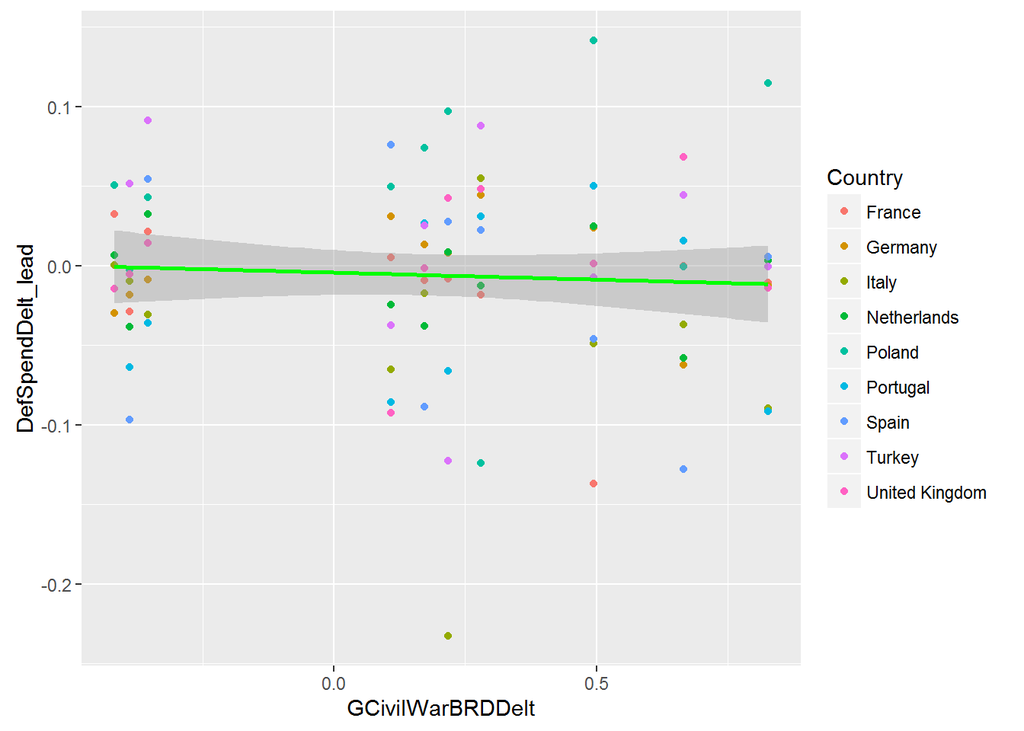

```r
    ggplot(data=EuropeOmnibus,aes(x=GCivilWarBRDDelt,
                            y=DefSpendDelt_lead,
                            color=Country))+geom_point()+stat_smooth(method = "lm", col = "green")
```

```r
reg<-13
lmMoreDef[reg]<-list(lm(log(DefSpend_lead) ~ DefSpread_lag1 + log(NGDPPC_eu2014)+
                            log(Population)+Debt_NGDP+EUdebt_NGDP+Dfc_NGDP+UNmilitaryPMil+IntAt+
                            log(GCivilWarBRD),
                        EuropeMoreDef))
lmEUldr[reg]<-list(lm(log(DefSpend_lead) ~ EUldrSpread_lag1 + log(NGDPPC_eu2014)+
                            log(Population)+Debt_NGDP+EUdebt_NGDP+Dfc_NGDP+UNmilitaryPMil+IntAt+
                            log(GCivilWarBRD),
                      EuropeEUleadership))
lmNATOess[reg]<-list(lm(log(DefSpend_lead) ~ NATOessSpread_lag1 + log(NGDPPC_eu2014)+
                            log(Population)+Debt_NGDP+EUdebt_NGDP+Dfc_NGDP+UNmilitaryPMil+IntAt+
                            log(GCivilWarBRD),
                        EuropeNATOess))
lmEU_UScls[reg]<-list(lm(log(DefSpend_lead) ~ EUcloserUSspread_lag1+ log(NGDPPC_eu2014)+
                            log(Population)+Debt_NGDP+EUdebt_NGDP+Dfc_NGDP+UNmilitaryPMil+IntAt+
                            log(GCivilWarBRD),
                         EuropeEUcloserUS))
nModel[reg]<-"gCivilWarBRD"


# screenreg(c(lmMoreDef[c(12,14:15)],
#                lmEUldr[c(12,14:15)],
#                lmNATOess[c(12,14:15)],
#                lmEU_UScls[c(12,14:15)]),
#                custom.model.names=c(rep(nModel[c(12,14:15)],4)))


screenreg(c(lmMoreDef[c(12:13)],
            lmEUldr[c(12:13)],
            lmNATOess[c(12:13)],
            lmEU_UScls[c(12:13)]),
          custom.model.names=c(rep(nModel[c(12:13)],4)),
              stars=c(0.001,0.01,0.05,0.1),
        reorder.coef=c(1,2,11,12,13,3,4,5,6,7,8,9,10),
          groups = list("Intercept" = 1,"Polling" = 2:5,"Macroeconomic" = 6:9,"Security"=10:13))
```

```
##
## =============================================================================================================================
##                            IntAt      gCivilWarBRD  IntAt      gCivilWarBRD  IntAt      gCivilWarBRD  IntAt      gCivilWarBRD
## -----------------------------------------------------------------------------------------------------------------------------
## Intercept
##
##     (Intercept)            -3.63 ***  -3.68 **      -3.03 ***  -2.30 *       -4.74 ***  -5.44 ***     -4.47 ***  -4.69 ***
##                            (0.87)     (1.09)        (0.84)     (1.11)        (0.79)     (0.94)        (0.99)     (1.32)
## Polling
##
##     DefSpread_lag1          0.72 ***   0.71 ***
##                            (0.18)     (0.18)
##     EUldrSpread_lag1                                -1.06 ***  -1.16 ***
##                                                     (0.21)     (0.23)
##     NATOessSpread_lag1                                                        0.70 **    0.77 **
##                                                                              (0.26)     (0.27)
##     EUcloserUSspread_lag1                                                                             -0.41      -0.34
##                                                                                                       (0.30)     (0.40)
## Macroeconomic
##
##     log(NGDPPC_eu2014)      0.95 ***   0.94 ***      0.92 ***   0.92 ***      0.78 ***   0.77 ***      0.82 ***   0.83 ***
##                            (0.06)     (0.06)        (0.06)     (0.06)        (0.06)     (0.06)        (0.10)     (0.12)
##     log(Population)         1.04 ***   1.04 ***      1.07 ***   1.06 ***      1.17 ***   1.18 ***      1.15 ***   1.14 ***
##                            (0.04)     (0.04)        (0.04)     (0.04)        (0.04)     (0.04)        (0.05)     (0.06)
##     Debt_NGDP               0.00       0.00          0.00       0.00         -0.00      -0.00         -0.00      -0.00
##                            (0.00)     (0.00)        (0.00)     (0.00)        (0.00)     (0.00)        (0.00)     (0.00)
##     EUdebt_NGDP            -0.01 *    -0.01         -0.01 ***  -0.01 *       -0.01 *    -0.01 *       -0.01      -0.01
##                            (0.00)     (0.01)        (0.00)     (0.00)        (0.00)     (0.00)        (0.01)     (0.01)
## Security
##
##     Dfc_NGDP                0.01       0.01         -0.01      -0.00         -0.01      -0.01         -0.03 **   -0.03 *
##                            (0.01)     (0.01)        (0.01)     (0.01)        (0.01)     (0.01)        (0.01)     (0.01)
##     UNmilitaryPMil         -0.00      -0.00         -0.01 ***  -0.01 **      -0.00      -0.00         -0.01 *    -0.01 *
##                            (0.00)     (0.00)        (0.00)     (0.00)        (0.00)     (0.00)        (0.00)     (0.00)
##     IntAt                   0.08 *     0.08 *        0.11 ***   0.11 **       0.09 **    0.10 **       0.13 **    0.13 **
##                            (0.03)     (0.04)        (0.03)     (0.03)        (0.03)     (0.03)        (0.05)     (0.05)
##     log(GCivilWarBRD)                  0.01                    -0.08                     0.09                     0.03
##                                       (0.12)                   (0.08)                   (0.07)                   (0.12)
## -----------------------------------------------------------------------------------------------------------------------------
## R^2                         0.98       0.98          0.97       0.97          0.96       0.96          0.95       0.95
## Adj. R^2                    0.97       0.97          0.96       0.96          0.95       0.95          0.95       0.95
## Num. obs.                  53         53            70         70            87         87            64         64
## RMSE                        0.20       0.20          0.19       0.19          0.21       0.21          0.23       0.23
## =============================================================================================================================
## *** p < 0.001, ** p < 0.01, * p < 0.05, . p < 0.1
```

## 2.4 Parliamentary Opinion Controls

### 2.4.1 Cabinet Left/Right vs. Liberty/Security

```r
corrdisp<-rcorr(as.matrix(subset(EuropeOmnibus, select=c(DefSpread_lag1,
                                               EUldrSpread_lag1,
                                               NATOessSpread_lag1,
                                               EUcloserUSspread_lag1,
                                               NGDPPC_eu2014,
                                               Population,
                                               Debt_NGDP,
                                               EUdebt_NGDP,
                                               Dfc_NGDP,
                                               UNmilitaryPMil,
                                               IntAt,
                                               GCivilWarBRDDelt,
                                               Cab_left_right,
                                               Cab_liberty_authority,
                                               Cab_eu_anti_pro,
                                               left_right_ls_spread,
                                               liberty_authority_ls_spread,
                                               eu_anti_pro_ls_spread
                                               ))))

corrdisp[[1]][,13:15]
```

```
##                             Cab_left_right Cab_liberty_authority Cab_eu_anti_pro
## DefSpread_lag1                 -0.20176303           -0.22743763    -0.015672835
## EUldrSpread_lag1               -0.30372736           -0.49618837    -0.104886964
## NATOessSpread_lag1             -0.16860929           -0.24810788    -0.315991819
## EUcloserUSspread_lag1           0.12871924           -0.05707016    -0.017193060
## NGDPPC_eu2014                  -0.06166961           -0.16587603    -0.413837343
## Population                      0.17556316            0.30861363    -0.132808819
## Debt_NGDP                       0.14432190            0.08286692    -0.385484338
## EUdebt_NGDP                     0.26224399            0.12719211    -0.066083871
## Dfc_NGDP                        0.03182649            0.13060461     0.096905679
## UNmilitaryPMil                 -0.03406460           -0.07927255    -0.143855512
## IntAt                           0.15946037            0.12478379    -0.164174676
## GCivilWarBRDDelt                0.08252746            0.07079767     0.004612222
## Cab_left_right                  1.00000000            0.88218254    -0.423975348
## Cab_liberty_authority           0.88218254            1.00000000    -0.338471979
## Cab_eu_anti_pro                -0.42397535           -0.33847198     1.000000000
## left_right_ls_spread            0.26668990            0.25826821    -0.203254938
## liberty_authority_ls_spread     0.01630451            0.06485517     0.066356748
## eu_anti_pro_ls_spread           0.03107326            0.09304278    -0.442269325
```

```r
corrdisp[[1]][,16:18]
```

```
##                             left_right_ls_spread liberty_authority_ls_spread eu_anti_pro_ls_spread
## DefSpread_lag1                      -0.101177312                -0.048193082            0.54937232
## EUldrSpread_lag1                     0.090360053                 0.104035832           -0.22941305
## NATOessSpread_lag1                  -0.161138758                -0.331366152            0.01305987
## EUcloserUSspread_lag1               -0.078688711                 0.159596637            0.13006178
## NGDPPC_eu2014                        0.165400565                -0.286332756           -0.22754544
## Population                           0.349703819                 0.073128507           -0.10092360
## Debt_NGDP                            0.311464220                 0.173275128           -0.15554740
## EUdebt_NGDP                         -0.099923588                -0.150355011           -0.11584584
## Dfc_NGDP                            -0.003568863                -0.102355301           -0.11321846
## UNmilitaryPMil                       0.421939164                 0.440704137           -0.03304378
## IntAt                                0.277546406                 0.003967728           -0.16765410
## GCivilWarBRDDelt                    -0.180753738                -0.107952982           -0.08981667
## Cab_left_right                       0.266689897                 0.016304506            0.03107326
## Cab_liberty_authority                0.258268207                 0.064855166            0.09304278
## Cab_eu_anti_pro                     -0.203254938                 0.066356748           -0.44226933
## left_right_ls_spread                 1.000000000                 0.714473188           -0.28049380
## liberty_authority_ls_spread          0.714473188                 1.000000000           -0.10882794
## eu_anti_pro_ls_spread               -0.280493796                -0.108827941            1.00000000
```

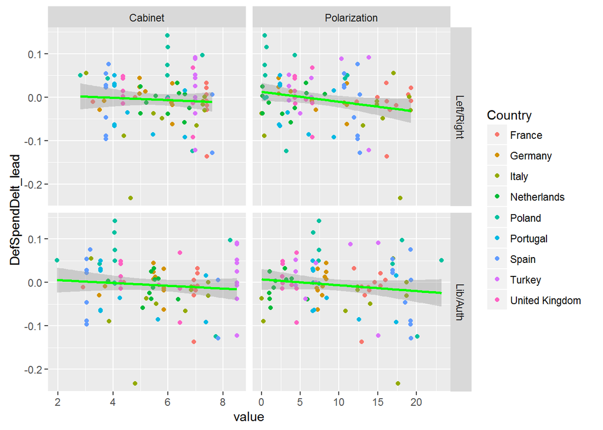

```r
LeftRightVsLibAuthScatter <- melt(EuropeOmnibus, measure.vars = c("Cab_left_right",
                                           "left_right_ls_spread",
                                           "Cab_liberty_authority",
                                           "liberty_authority_ls_spread"))
LeftRightVsLibAuthScatter$Measure<-NA
LeftRightVsLibAuthScatter$Measure[LeftRightVsLibAuthScatter$variable %in%
                          c("Cab_left_right","Cab_liberty_authority")]<-"Cabinet"
LeftRightVsLibAuthScatter$Measure[is.na(LeftRightVsLibAuthScatter$Measure)]<-"Polarization"
LeftRightVsLibAuthScatter$Score<-NA
LeftRightVsLibAuthScatter$Score[LeftRightVsLibAuthScatter$variable %in%
                          c("Cab_left_right","left_right_ls_spread")]<-"Left/Right"
LeftRightVsLibAuthScatter$Score[is.na(LeftRightVsLibAuthScatter$Score)]<-"Lib/Auth"

    ggplot(data=LeftRightVsLibAuthScatter,aes(x=value,
                            y=DefSpendDelt_lead,
                            color=Country))+geom_point()+
        facet_grid(Score~Measure , scales="free_x")+stat_smooth(method = "lm", col = "green")
```